# Topic 1

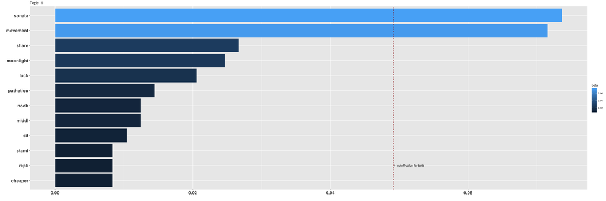

On interpreting beta: the term has a beta probability of being generated from the particular topic.

Values below are gamma : An estimated proportion of words from that document that are generated from that topic.

**Text Record Number: 1317** gamma: 28 % likelihood of this document (based on its words) in this topic

**Hi Everyone,

Borrowing the idea of “exercise progression” from gymnastics, street workout and bodyweight training (A series of exercises with increasing difficulty intended to bring you to a level of an element that is currently out of your reach), I wrote a Beethoven Sonata progression that is intended to bring me to the level of the coveted op. 53 Waldstein (at least the 1st movement).

I know this is miles and miles to go, as I’m currently at the level where I learn Mozart’s Fantasia in D minor, and starting the Chopin op. 64 Waltzes (I can play the Polonaise in G minor quite well). On the other hand, it is sometimes good to have long term goals to aspire to. So here’s the progression:

Sonata 25 op. 79  
Sonata 1 op.2 no.1  
Sonata 9 op. 14 no.1  
Sonata 5 op. 10 no. 1  
Sonata 3 op.2 no.3  
Sonata 8 op. 13 (Pathetique)  
Sonata 6 op. 10 no. 2  
Sonata 7 op. 10 no. 3  
Sonata 16 op. 31 no.1  
Sonata 17 op. 31 no.2 (tempest)  
Sonata 21 op. 53 (Waldstein) mvt. 1

Of course I don’t intend to learn only these pieces, but interlace them with pieces by Chopin, the more advanced Mozart sonatas and some by Debussy and maybe some Schubert and Mendelssohn. I will also probably don’t learn all of the entire sonatas, but chosen movements from them - the ones that more or less encapsulate the piece’s difficulty.

What do you think? Does this progression make sense? Are the later pieces too wide apart in terms of technique and musicality?

Thanks a lot,

Tom**

**Text Record Number: 456** gamma: 28 % likelihood of this document (based on its words) in this topic

**I played all 3 movements of Waldstein 8 yrs ago but spend around 1.5 years on the last one and never played it very well.

I don’t think Tempest and Pathetique are both required for 1st movement, if you can play Pathetique first movement, you should be able then progress into play Waldstein 1st movement.

My piano friend did Pathetique 3rd mvt into 1st mvt then into some really advanced stuff like Chopin etudes & Liszt etudes.**

**Text Record Number: 583** gamma: 28 % likelihood of this document (based on its words) in this topic

**Awesome!! I love the Pathetique, and it’s a major milestone for me in this list as well. And sounds like you’re well on your way - The no.1 sonata is really impressive and sounds quite hard to me, especially the last movement.

Can you please share what other pieces are you playing now / have een playing lately?

Best of luck with the sonata!**

**Text Record Number: 102** gamma: 28 % likelihood of this document (based on its words) in this topic

**Yes this is common and has an evolutionary background. Since the index finger and thumb are the most used (and somehow most important) fingers, they evolved to be independently controllable.

“*The little finger actually moves easier than the middle and ring fingers. That’s because it also has independent muscles for some movements. However, it also relies on muscles shared with the other three fingers for some actions, thereby limiting your control.*” - indiatimes.com

If my interpretation is correct, your pinky “jumps” when you move either your ring or middle finger because they share some common muscles. I know it from playing guitar, you can train your hand and fingers to be more independent, but it takes a lot of exercise and time as such are unnatural movements for your fingers.

Just keep exercising and try to find some easy training to enforce the independence of your fingers. Don’t get frustrated, it is really a hard task.**

**Text Record Number: 577** gamma: 28 % likelihood of this document (based on its words) in this topic

**I am still quite a noob imo,considering the fact that I am still learning the first movement I quite like the second movement but the third movement is quite scary ngl and I don’t think I can learn it any time soon. I thought the Beethoven was a bit dry after practicing for some time so I decided to learn Mozart sonata 16 and it’s quite enjoyable to play**

**Text Record Number: 94** gamma: 28 % likelihood of this document (based on its words) in this topic

**the first movement of the moonlight sonata for example**

**Text Record Number: 1014** gamma: 28 % likelihood of this document (based on its words) in this topic

**Making aspiring students play an instrument with incorrect technique is doing them dirty. This is a problem that needs to be taken care of as quickly as possible. If you need the acoustic, ask for the acoustic. If you keep getting slapped with BS bureaucratic explanations as to why you can’t get the acoustic, then I would suggest getting a height adjustable stand and height adjustable bench. They don’t have to be anything fancy, and for the most part digital piano stands are universal and work with damn near any of them. This would at least let you adjust both so you can get your students sitting the way they are supposed to. I for one would be furious if I was paying for music lessons from a private institution and slowly discovered they were making me practice with the wrong posture and technique, because someone in upper manglement was too annoyed to get the right equipment for the teacher trying to do their job.**